# Competing Risks2026 Practicals I

Author

Ronald Geskus

Published

### Data

In the competing risks practical, we only use information on relapse and death. We investigate the role of the EBMT risk score. The EBMT score is a combination of donor-recipient match and age of the recipient, among other things. It divides patients into three risk groups. The event time and event status are in the columns `srv` and `srvstat`.

- Load the R packages, `mstate` also loads the `survival` package. It contains the data for this practice

```r
library(mstate)
library(ggsurvfit)
library(survminer)
data(ebmt1)
```

### 1. A first look at the data

- Have a look at the help file of the `ebmt1` data set. Note that time is measured in days from transplantation, and the EBMT risk score is called `score`.

```r
?ebmt1
```

- Inspect the data by looking at the first couple of individuals or by viewing the complete data set. Summarize all the variables. How many relapses were observed and how many deaths? Why are there 1521 NA’s in the yrel variable?
- Summary of the data

```r
summary(ebmt1)
```

```
     patid           srv            srvstat            rel            relstat
 Min.   :   1   Min.   :   0.5   Min.   :0.0000   Min.   :   0.5   Min.   :0.0000
 1st Qu.: 495   1st Qu.: 157.0   1st Qu.:0.0000   1st Qu.: 113.0   1st Qu.:0.0000
 Median : 989   Median : 692.0   Median :0.0000   Median : 395.0   Median :0.0000
 Mean   : 989   Mean   : 854.5   Mean   :0.4411   Mean   : 701.3   Mean   :0.2307
 3rd Qu.:1483   3rd Qu.:1400.0   3rd Qu.:1.0000   3rd Qu.:1127.0   3rd Qu.:0.0000
 Max.   :1977   Max.   :3088.0   Max.   :1.0000   Max.   :3088.0   Max.   :1.0000
        yrel           age                score
 1993-1996: 103   Min.   : 0.00   Low risk   : 406
 1997-1999: 208   1st Qu.:28.00   Medium risk:1404
 2000-    : 145   Median :36.00   High risk  : 167
 NA's     :1521   Mean   :35.81
                  3rd Qu.:45.00
                  Max.   :64.00
```

- Number of relapses and deaths

```r
table(ebmt1$srvstat)
```

```
   0    1
1105  872
```

```r
table(ebmt1$relstat)
```

```
   0    1
1521  456
```

There are 1521 missings (NA) in the variable `yrel` because these individuals did not have a relapse observed.

### 2. Estimation of relapse-free survival

Compute the Kaplan-Meier estimator for relapse-free survival. Give the estimate of the median relapse-free survival time. Obtain the estimates of at one and five years. Plot the survival curve with 95% confidence intervals and the “at risk” table.

- Compute KM estimator and median survival time using `survfit` function. The `Surv` function creates a survival object for use as a response in a model formula. The result is a so-called `survfit` object, for which a number of functions (*methods* is the better word) are defined. If you just give the name of the object as command, the `print` method is invoked. It contains some very basic information on the relapse-free event-time curve, such as the median time.

```r
KM.overall <- survfit(Surv(srv,srvstat)~1, data=ebmt1)
KM.overall # gives median value
```

```
Call: survfit(formula = Surv(srv, srvstat) ~ 1, data = ebmt1)

        n events median 0.95LCL 0.95UCL
[1,] 1977    872   2537    1828      NA
```

- More detailed information is made visible using the `summary` function. It shows the event times, and the Kaplan-Meier estimate at those time points, and also other useful things like the numbers at risk, number of events etcetera. It has an argument `times` that we use to obtain relapse-free survival only at one and five years. If we want the time shown in years, we specify `scale=365.25`.

```r
summary(KM.overall, times=c(1,5)*365.25)
```

```
Call: survfit(formula = Surv(srv, srvstat) ~ 1, data = ebmt1)

 time n.risk n.event survival std.err lower 95% CI upper 95% CI
  365   1199     698    0.640  0.0109        0.619        0.662
 1826    273     165    0.524  0.0126        0.500        0.550
```

- Plot the estimate of the cumulative incidence with 95% confidence intervals. A `survfit` object also has a `plot` method, which plots a Kaplan-Meier survival curve. The `fun` argument is used to plot on the complementary scale of the cumulative incidence. The `xscale` argument allows to label time in years. The `las` argument rotates the labels along the y-axis.

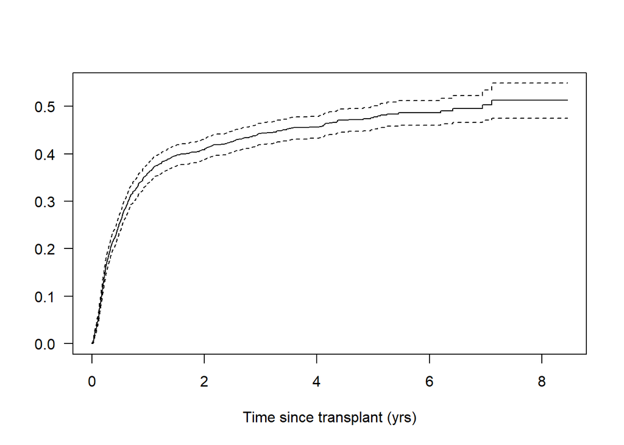

```r
plot(KM.overall, xlab="Time since transplant (yrs)", fun="event", xscale=365.25, las=1)
```

- We also show the plot using the `ggsurvfit` in the R library `ggsurvfit`.

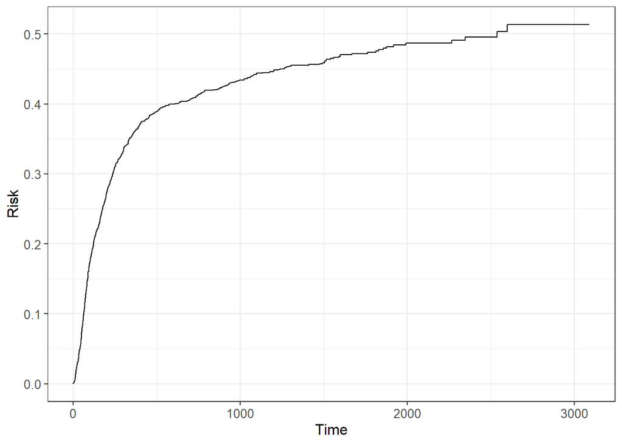

```r
ggsurvfit(KM.overall, type="risk")
```

It is straightforward to add an “at risk” table. We need to use `ggplot2` functionality to label time in years.

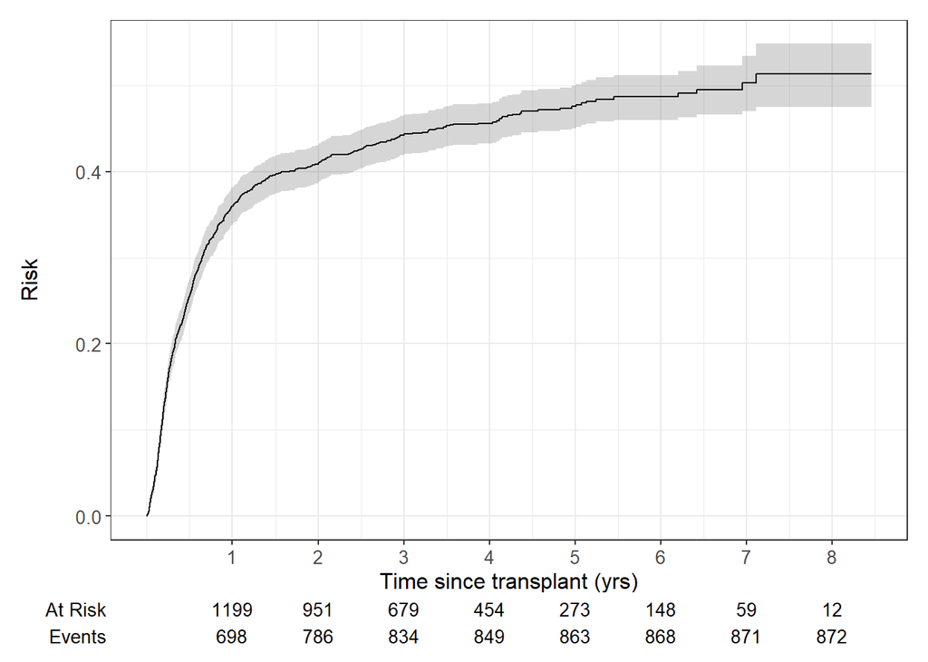

```r
ggsurvfit(KM.overall, type="risk") +
  add_confidence_interval() +
  add_risktable() +
  scale_x_continuous("Time since transplant (yrs)", labels=1:8, breaks=365.25*(1:8))
```

- We also show the plot using the `ggsurvplot` in the R library `survminer`.

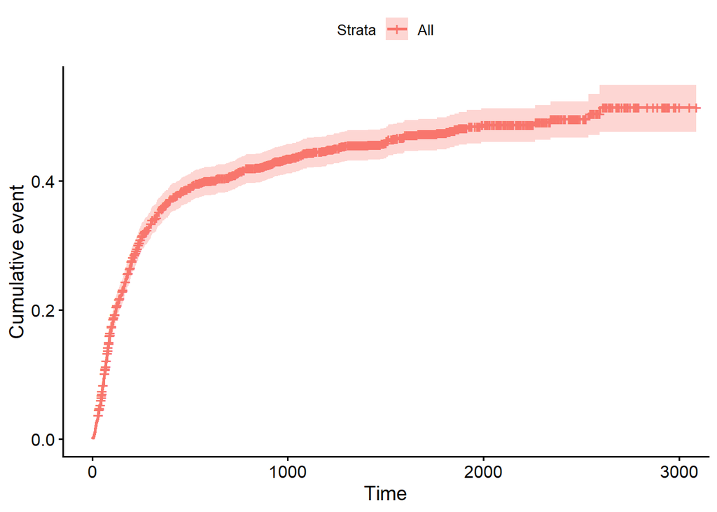

```r
ggsurvplot(KM.overall, fun="event")
```

Again, we make some adaptations.

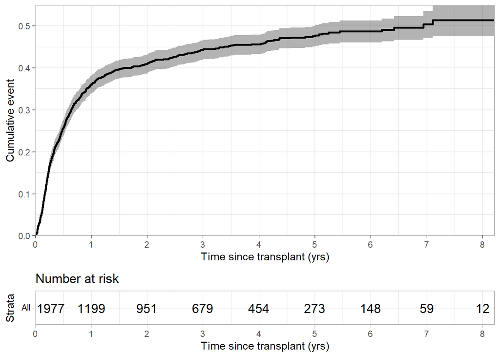

```r
ggsurvplot(KM.overall, fun="event", palette="black", risk.table=TRUE, censor=FALSE,
           xscale=365.25, break.x.by=365.25, xlab="Time since transplant (yrs)",
           axes.offset=FALSE, legend="none", ggtheme=theme_light())
```

### 3. Relapse-free survival by value of score.

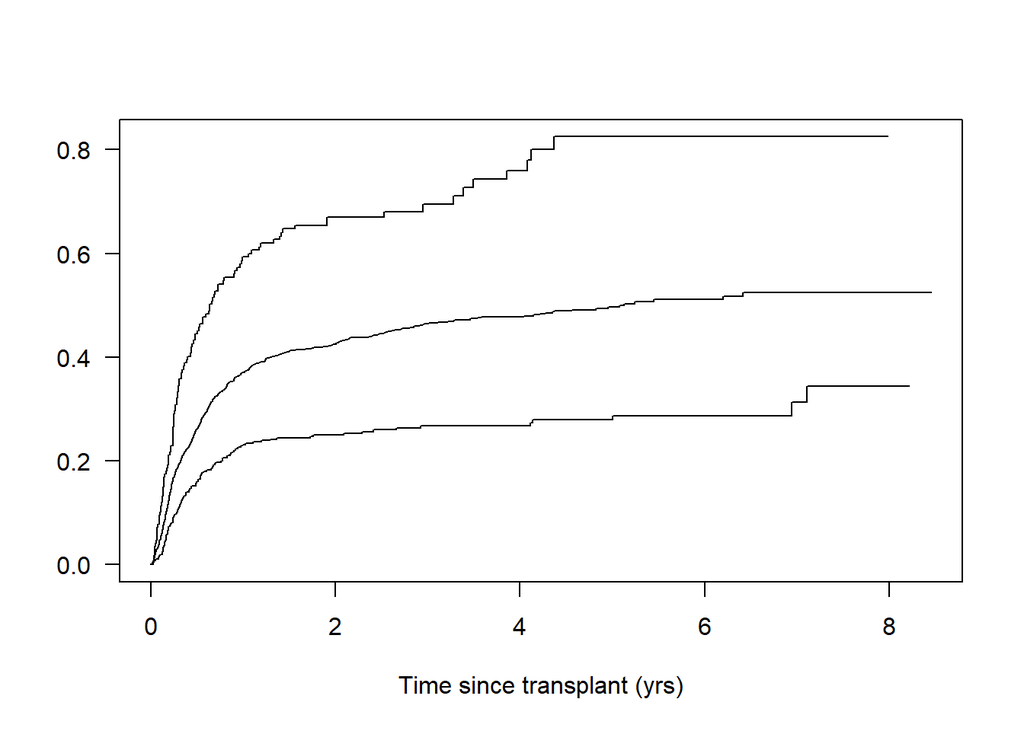

```r
plot(survfit(Surv(srv,srvstat) ~ score, data = ebmt1),
     xlab="Time since transplant (yrs)", fun="event", xscale=365.25, las=1)
```

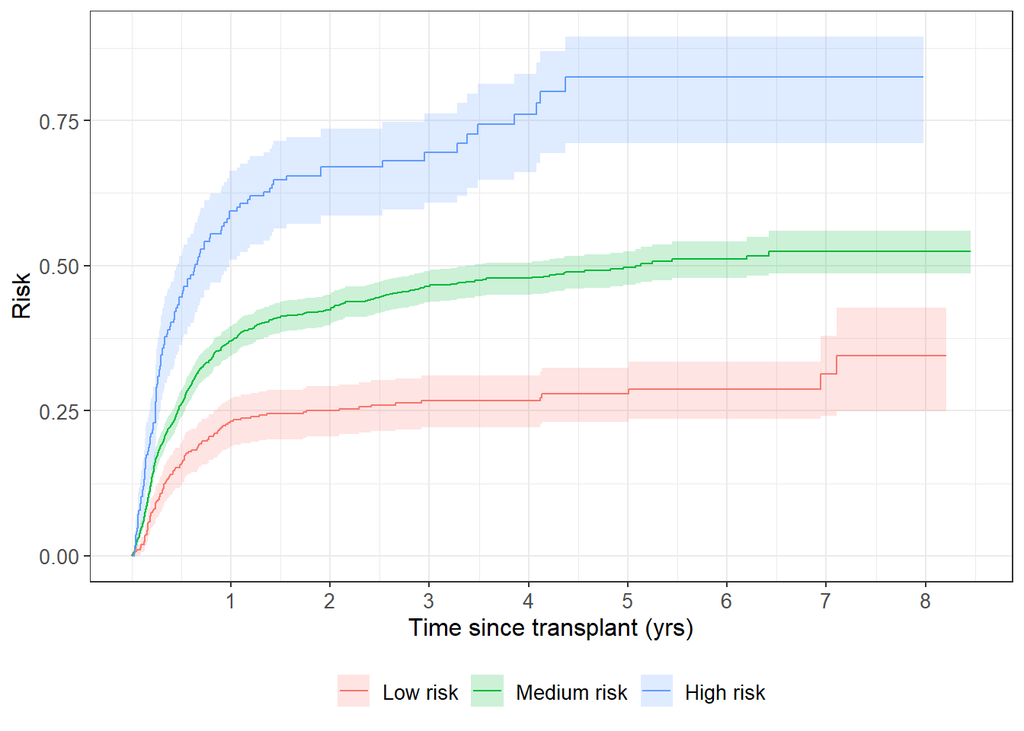

```r
ggsurvfit(survfit2(Surv(srv,srvstat) ~ score, data = ebmt1), type="risk") +
    add_confidence_interval() +
    scale_x_continuous("Time since transplant (yrs)", labels=1:8, breaks=365.25*(1:8))
```

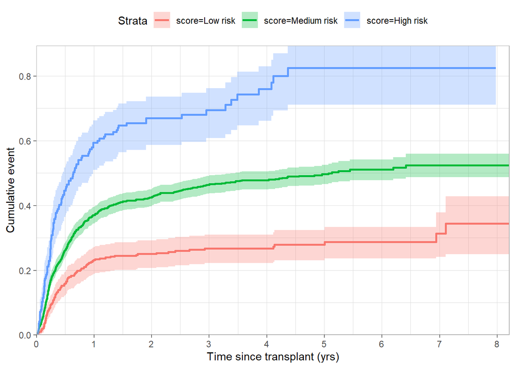

```r
ggsurvplot(survfit(Surv(srv,srvstat) ~ score, data = ebmt1), fun="event",
           censor=FALSE, xscale=365.25, break.x.by=365.25,
           conf.int=TRUE, xlab="Time since transplant (yrs)",
           axes.offset=FALSE, ggtheme=theme_light())
```

- Fit a proportional hazards model for relapse-free survival using the function `coxph`. Just like with the `survfit` function, the `print` function gives a short summary of the model fit, whereas the `summary` function gives more details. Again, if only the name of the object is specified, the print function is assumed.

```r
PH.relsurv <- coxph(Surv(srv,srvstat) ~ score, data = ebmt1)
PH.relsurv
```

```
Call:
coxph(formula = Surv(srv, srvstat) ~ score, data = ebmt1)

                   coef exp(coef) se(coef)      z        p
scoreMedium risk 0.6845    1.9827   0.1036  6.605 3.99e-11
scoreHigh risk   1.3766    3.9615   0.1339 10.280  < 2e-16

Likelihood ratio test=106.3  on 2 df, p=< 2.2e-16
n= 1977, number of events= 872
```

```r
summary(PH.relsurv)
```

```
Call:
coxph(formula = Surv(srv, srvstat) ~ score, data = ebmt1)

  n= 1977, number of events= 872

                   coef exp(coef) se(coef)      z Pr(>|z|)
scoreMedium risk 0.6845    1.9827   0.1036  6.605 3.99e-11 ***
scoreHigh risk   1.3766    3.9615   0.1339 10.280  < 2e-16 ***
---
Signif. codes:  0 '***' 0.001 '**' 0.01 '*' 0.05 '.' 0.1 ' ' 1

                 exp(coef) exp(-coef) lower .95 upper .95
scoreMedium risk     1.983     0.5044     1.618     2.429
scoreHigh risk       3.962     0.2524     3.047     5.151

Concordance= 0.575  (se = 0.008 )
Likelihood ratio test= 106.3  on 2 df,   p=<2e-16
Wald test            = 105.8  on 2 df,   p=<2e-16
Score (logrank) test = 113.3  on 2 df,   p=<2e-16
```

The hazard ratios are in the column `exp(coef)`. We see that those with medium and high value of the EBMT score have a significantly higher rate of losing the event-free survival status.